# Segmentation of Trip Data - Part4

Dave Hurst

Tuesday, December 30, 2014

## Build trip profiles

I wrote `tripProfile` to count the number of *straight, accelerating*, and *decelerating* segments along with some characteristics (see at the bottom).

Here’s what it comes up with for the driver we’ve been working with:

```r
driver.id <- 2591

trip.prof <- data.frame()
ptime0 <- proc.time()
for(i.trip in 1:200) {
    trip <- getTrip( driver.id, i.trip, v.thresh=1 )    #v.thresh = lowered for slow trips
    tp <- getTripProfile( trip )
    trip.prof <- rbind(trip.prof, tp)
    cat(i.trip, ": length, dist, straights, accels, decels # ", tp$trip.len, round(tp$trip.dist/1000,1), tp$ss.n, tp$acc.n, tp$dec.n, "...\n")
}
```

```
## 1 : length, dist, straights, accels, decels #  649 11.5 5 5 7 ...
## 2 : length, dist, straights, accels, decels #  290 1.9 1 1 3 ...
## 3 : length, dist, straights, accels, decels #  836 11.7 4 4 5 ...
## 4 : length, dist, straights, accels, decels #  637 7.8 2 3 3 ...
## 5 : length, dist, straights, accels, decels #  923 15.8 9 9 9 ...
## 6 : length, dist, straights, accels, decels #  194 1.4 0 1 3 ...
## 7 : length, dist, straights, accels, decels #  283 3.7 1 0 2 ...
## 8 : length, dist, straights, accels, decels #  765 11 2 5 5 ...
## 9 : length, dist, straights, accels, decels #  604 7.6 3 6 6 ...
## 10 : length, dist, straights, accels, decels #  574 4.2 2 5 5 ...
## 11 : length, dist, straights, accels, decels #  234 3 1 1 2 ...
## 12 : length, dist, straights, accels, decels #  933 14.6 10 14 14 ...
## 13 : length, dist, straights, accels, decels #  583 6.1 1 8 9 ...
## 14 : length, dist, straights, accels, decels #  1319 23 13 9 8 ...
## 15 : length, dist, straights, accels, decels #  752 10.3 6 6 10 ...
```

[output cut: 185 more lines]

```r
rownames(trip.prof) <- 1:200
ptime1 <- proc.time()
print (ptime1 - ptime0)
```

```
##    user  system elapsed
##   65.02    0.09   66.49
```

## Notes / Observations

### Trip 7

Trip 7 shows a break in the deceleration (downshift?). This can be smoothed out by increasing the MA value (I added a parameter for `segment.parse.XXcel`), but do we want to? Notice the value for *a.mid* (the midpoint deceleration value changes significantly).

One idea (for parse.decel) would be to pre-process the segment with a very high MA to get the boundaries of the segment, but process it with better resolution. It’s interesting for this graph that both segments are steeper than the smoothed segment, but the fact that there is a “stutter” could be predictive, so we probably don’t want lose that (but will for now).

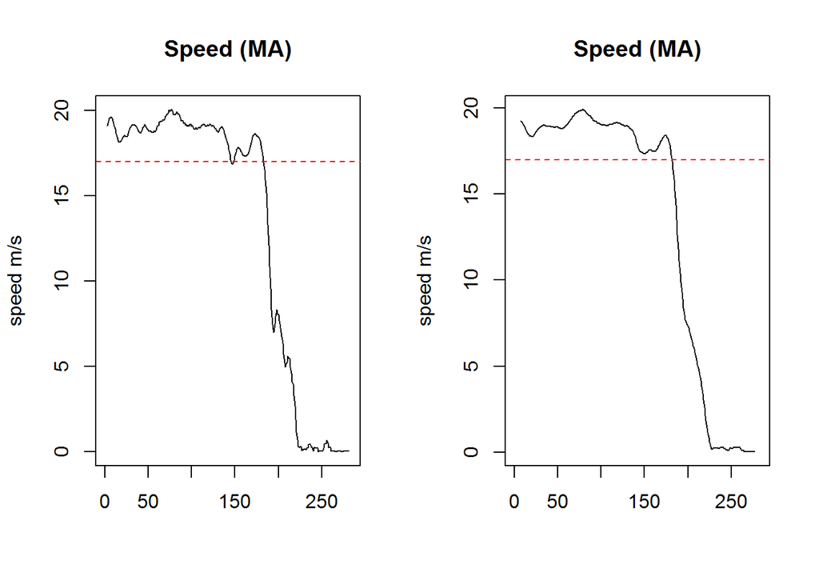

```r
i.trip=7
trip <- getTrip( driver.id, i.trip, v.thresh=1 )
#tp <- getTripProfile( trip )  #this originally had a warning message which lead me to look at this trip
par.orig <- par(mfrow=c(1,2))
plotTripSegment.speed(trip,1,999)
plotTripSegment.speed(trip,1,999, ma=13)
```

```r
par(par.orig)
segment.parse.decel(trip) #default ma=5
```

```
##    t0  tn        v0        vn      a.mid
## 1 173 195 18.634334 7.0068556 -0.6109059
## 2 213 224  5.483521 0.2532381 -0.6088018
```

```r
segment.parse.decel(trip, ma=13)
```

```
##    t0  tn       v0        vn      a.mid
## 1 174 228 18.42091 0.1594338 -0.1868061
```

### Trip 72

```r
#with(trip.prof, print(trip.prof[ss.n * acc.n * dec.n == 0,  c("ss.n", "acc.n", "dec.n")]))
miss.1   <- with(trip.prof, print(which(ss.n * acc.n * dec.n == 0 )))
```

```
##  [1]   6   7  30  40  45  46  60  72  79  82 104 115 122 123 131 147 151
## [18] 152 153 154 155 157 163 187 196 198
```

```r
miss.all <- with(trip.prof, print(which(ss.n + acc.n + dec.n == 0 )))
```

```
## [1] 72
```

```r
cat ("Trips missing at least one segment type:\n", miss.1, "\n")
```

```
## Trips missing at least one segment type:
##  6 7 30 40 45 46 60 72 79 82 104 115 122 123 131 147 151 152 153 154 155 157 163 187 196 198
```

```r
cat ("Trips with no segment type:\n"             , miss.all, "\n")
```

```
## Trips with no segment type:
##  72
```

```r
i.trip <- 72
tp <- trip.prof[i.trip, ]
cat(i.trip, ": length, dist, straights, accels, decels # ", tp$trip.len, round(tp$trip.dist/1000,1), tp$ss.n, tp$acc.n, tp$dec.n, "...\n")
```

```
## 72 : length, dist, straights, accels, decels #  476 0.1 0 0 0 ...
```

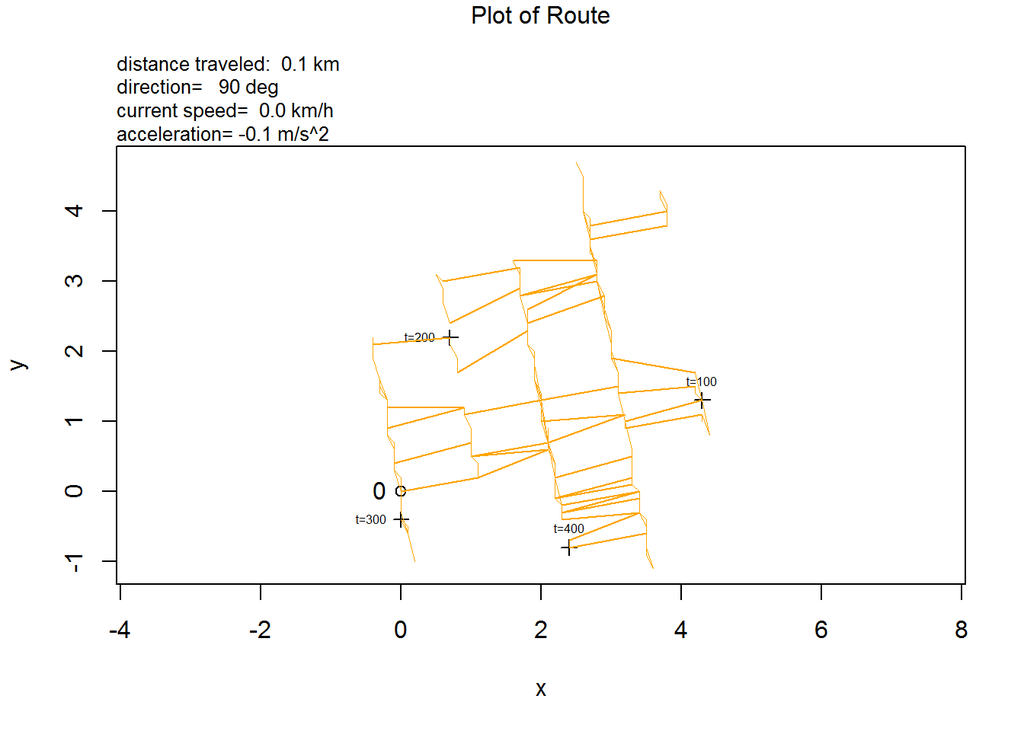

```r
trip <- getTrip( driver.id, i.trip, v.thresh=1 )
plotTrip(trip)
```

This looks like a parked car, and is probably all noise. We should filter trips like these out.

```r
trip.prof <- trip.prof[-miss.all, ]
print(summary( trip.prof ))
```

```
##     trip.len        trip.dist         speed.avg         speed.max
##  Min.   : 156.0   Min.   :  389.7   Min.   : 0.5932   Min.   :11.70
##  1st Qu.: 282.5   1st Qu.: 2337.5   1st Qu.: 7.4073   1st Qu.:19.42
##  Median : 502.0   Median : 5574.0   Median :12.3856   Median :22.64
##  Mean   : 637.4   Mean   : 8091.0   Mean   :11.2906   Mean   :22.81
##  3rd Qu.: 935.0   3rd Qu.:12821.6   3rd Qu.:14.7602   3rd Qu.:25.11
##  Max.   :1634.0   Max.   :26772.4   Max.   :21.9898   Max.   :73.72
##
##       ss.n          ss.len.min       ss.len.max      ss.len.avg
##  Min.   : 0.000   Min.   : 30.00   Min.   : 31.0   Min.   : 31.00
##  1st Qu.: 1.000   1st Qu.: 34.00   1st Qu.: 65.0   1st Qu.: 55.60
##  Median : 2.000   Median : 41.00   Median :109.0   Median : 72.50
##  Mean   : 3.819   Mean   : 72.44   Mean   :128.4   Mean   : 95.17
##  3rd Qu.: 7.000   3rd Qu.: 68.00   3rd Qu.:202.0   3rd Qu.:111.57
##  Max.   :14.000   Max.   :276.00   Max.   :324.0   Max.   :276.00
##                   NA's   :22       NA's   :22      NA's   :22
##    ss.len.sd       ss.range.avg     ss.range.sd       ss.vmid.avg
##  Min.   :  0.00   Min.   : 4.004   Min.   : 0.2023   Min.   : 7.594
##  1st Qu.: 18.52   1st Qu.: 7.746   1st Qu.: 2.0483   1st Qu.:16.707
##  Median : 27.20   Median : 9.291   Median : 3.2904   Median :18.991
##  Mean   : 38.59   Mean   : 9.760   Mean   : 3.5570   Mean   :18.281
##  3rd Qu.: 52.93   3rd Qu.:11.350   3rd Qu.: 4.2197   3rd Qu.:20.389
##  Max.   :164.05   Max.   :23.666   Max.   :23.3281   Max.   :26.635
##  NA's   :89       NA's   :22       NA's   :89        NA's   :22
##    ss.vmid.sd         acc.n         acc.len.min     acc.len.max
##  Min.   :0.1554   Min.   : 0.000   Min.   : 5.00   Min.   : 7.00
##  1st Qu.:2.3346   1st Qu.: 2.000   1st Qu.: 9.00   1st Qu.:20.00
##  Median :3.7986   Median : 4.000   Median :12.00   Median :27.00
##  Mean   :3.6302   Mean   : 5.271   Mean   :13.38   Mean   :27.35
##  3rd Qu.:4.8894   3rd Qu.: 8.500   3rd Qu.:15.00   3rd Qu.:34.00
##  Max.   :8.8473   Max.   :23.000   Max.   :46.00   Max.   :55.00
##  NA's   :89                        NA's   :9       NA's   :9
##   acc.len.avg      acc.len.sd     acc.range.avg     acc.range.sd
##  Min.   : 7.00   Min.   : 0.000   Min.   : 5.149   Min.   :0.4921
##  1st Qu.:15.83   1st Qu.: 4.523   1st Qu.: 9.069   1st Qu.:2.6310
##  Median :18.71   Median : 7.112   Median :10.798   Median :3.6057
##  Mean   :19.49   Mean   : 7.098   Mean   :11.389   Mean   :3.8499
##  3rd Qu.:22.90   3rd Qu.: 9.589   3rd Qu.:13.098   3rd Qu.:5.0019
##  Max.   :46.00   Max.   :21.920   Max.   :23.098   Max.   :8.4599
##  NA's   :9       NA's   :49       NA's   :9        NA's   :49
```

[output cut: 25 more lines]

```
##  Min.   :0.1146   Min.   : 8.846   Min.   :0.5461   Min.   : 0.2223
##  1st Qu.:2.5001   1st Qu.:13.499   1st Qu.:3.2721   1st Qu.: 2.9215
##  Median :3.4471   Median :15.922   Median :4.4426   Median : 4.5580
##  Mean   :3.6195   Mean   :15.887   Mean   :4.3469   Mean   : 4.6805
##  3rd Qu.:4.7001   3rd Qu.:18.391   3rd Qu.:5.2062   3rd Qu.: 6.4360
##  Max.   :8.1558   Max.   :26.435   Max.   :9.2990   Max.   :12.0680
##  NA's   :20       NA's   :1        NA's   :20       NA's   :1
##    dec.vn.sd        dec.amid.avg      dec.amid.sd
##  Min.   :0.03015   Min.   :-2.2991   Min.   :0.001488
##  1st Qu.:2.67381   1st Qu.:-1.1420   1st Qu.:0.368631
##  Median :3.52872   Median :-0.9692   Median :0.474980
##  Mean   :3.52662   Mean   :-0.9932   Mean   :0.481462
##  3rd Qu.:4.36449   3rd Qu.:-0.7718   3rd Qu.:0.596342
##  Max.   :8.21409   Max.   :-0.1206   Max.   :1.224189
##  NA's   :20        NA's   :1         NA's   :20
```

```r
trip.id <- rownames(trip.prof[which.max(trip.prof$trip.len), ])
```

Just for grins, let’s take a look at the trip with the max length

```r
tp <- trip.prof[trip.id, ]
cat(trip.id, ": length, dist, straights, accels, decels # ", tp$trip.len, round(tp$trip.dist/1000,1), tp$ss.n, tp$acc.n, tp$dec.n, "...\n")
```

```
## 118 : length, dist, straights, accels, decels #  1634 15.8 11 20 19 ...
```

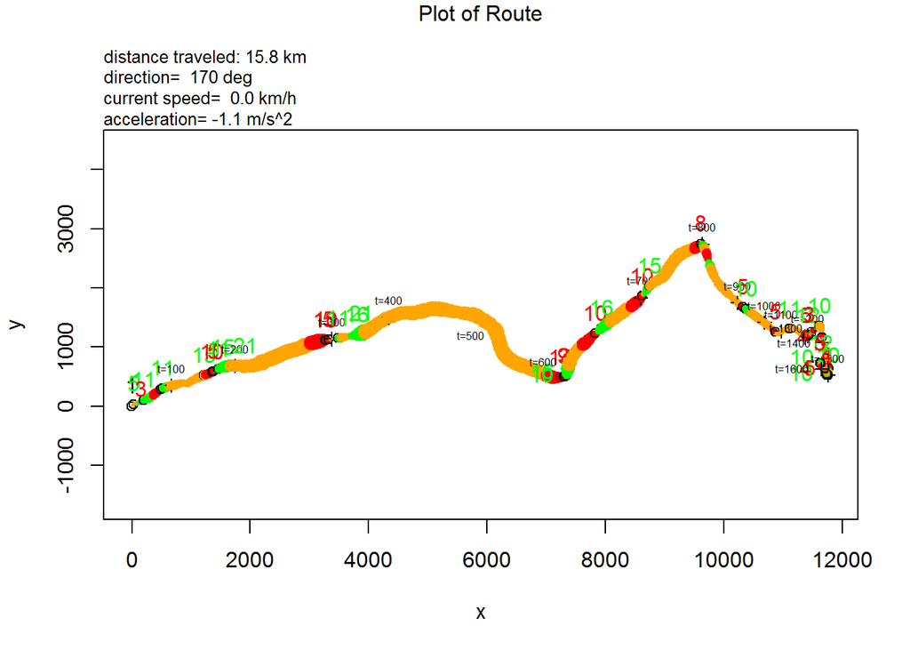

```r
trip <- getTrip( driver.id, trip.id, v.thresh=1 )
plotTrip(trip)
```

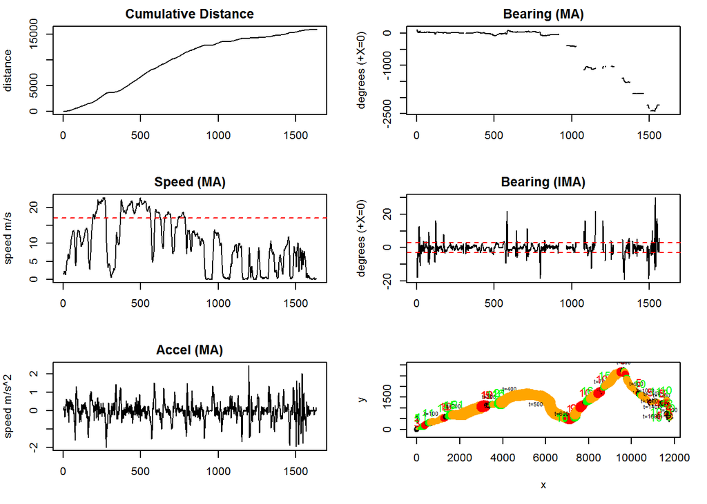

```r
plotTripSegment6(trip,1,9999)
```

```r
nfeat <- with(trip.prof, ss.n + acc.n + dec.n  )
trip.id <- rownames(trip.prof[which.max(nfeat), ])
```

```r
tp <- trip.prof[trip.id, ]
cat(trip.id, ": length, dist, straights, accels, decels # ", tp$trip.len, round(tp$trip.dist/1000,1), tp$ss.n, tp$acc.n, tp$dec.n, "...\n")
```

```
## 38 : length, dist, straights, accels, decels #  1455 18.8 12 23 22 ...
```

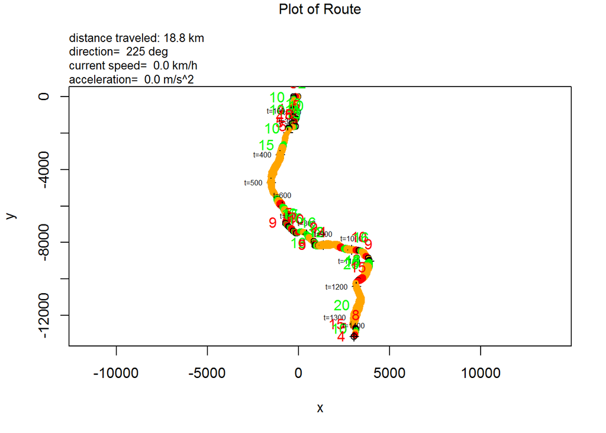

```r
trip <- getTrip( driver.id, trip.id, v.thresh=1 )
plotTrip(trip)
```

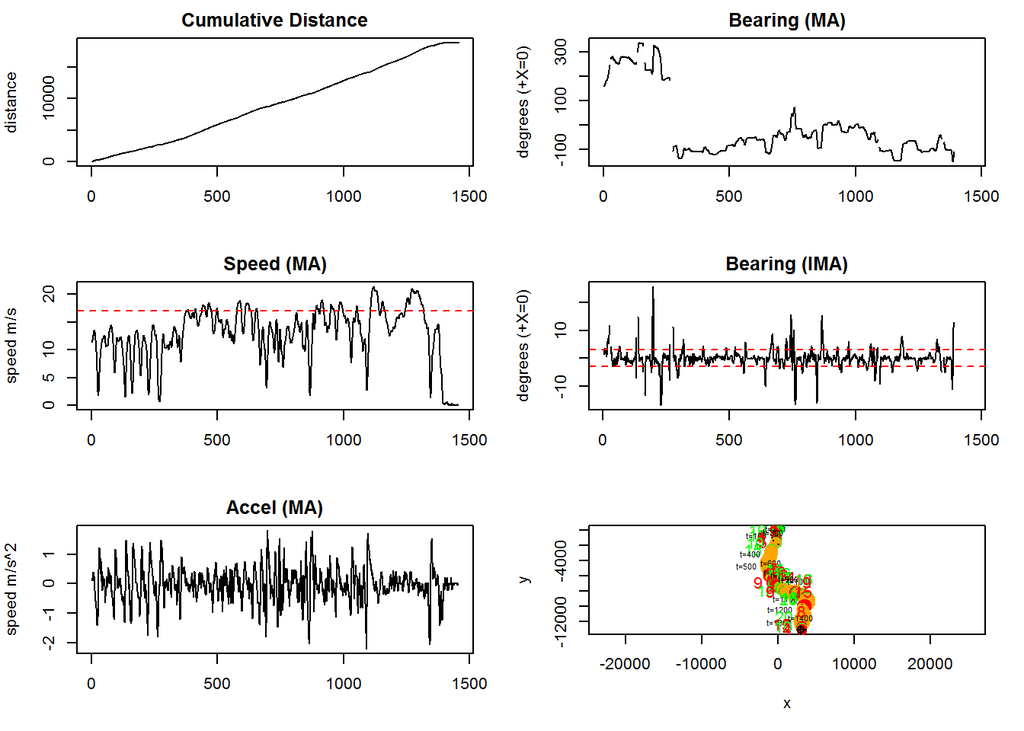

```r
plotTripSegment6(trip,1,9999)
```

```r
prof.fn <- sprintf("driver_%d_prof.RData", driver.id);
save(file=prof.fn, trip.prof)
```

```r
getTripProfile
```

```
## function (trip)
## {
##     prof <- data.frame(trip.len = nrow(trip))
##     prof$trip.dist <- sum(trip$v)
##     prof$speed.avg <- mean(trip$v)
##     prof$speed.max <- max(trip$v)
##     straights <- segment.parse.bearing(trip)
##     prof$ss.n <- nrow(straights)
##     if (nrow(straights) > 0) {
##         prof$ss.len.min <- min(straights$tlen)
##         prof$ss.len.max <- max(straights$tlen)
##         prof$ss.len.avg <- mean(straights$tlen)
##         prof$ss.len.sd <- sd(straights$tlen)
##         range <- (straights$v.max - straights$v.min)
##         prof$ss.range.avg <- mean(range)
##         prof$ss.range.sd <- sd(range)
##         prof$ss.vmid.avg <- mean(straights$v.mid)
##         prof$ss.vmid.sd <- sd(straights$v.mid)
##     }
##     else {
##         prof$ss.len.min <- prof$ss.len.max <- prof$ss.len.avg <- prof$ss.len.sd <- NA
##         prof$ss.range.avg <- prof$ss.range.sd <- prof$ss.vmid.avg <- prof$ss.vmid.sd <- NA
##     }
##     acc <- segment.parse.accel(trip)
##     prof$acc.n <- nrow(acc)
##     if (nrow(acc) > 0) {
##         len <- acc$tn - acc$t0
##         prof$acc.len.min <- min(len)
##         prof$acc.len.max <- max(len)
##         prof$acc.len.avg <- mean(len)
##         prof$acc.len.sd <- sd(len)
##         range <- (acc$vn - acc$v0)
##         prof$acc.range.avg <- mean(range)
##         prof$acc.range.sd <- sd(range)
##         prof$acc.v0.avg <- mean(acc$v0)
##         prof$acc.v0.sd <- sd(acc$v0)
##         prof$acc.vn.avg <- mean(acc$vn)
##         prof$acc.vn.sd <- sd(acc$vn)
##         prof$acc.amid.avg <- mean(acc$a.mid)
##         prof$acc.amid.sd <- sd(acc$a.mid)
```

[output cut: 16 more lines]

```
##         prof$dec.range.sd <- sd(range)
##         prof$dec.v0.avg <- mean(dec$v0)
##         prof$dec.v0.sd <- sd(dec$v0)
##         prof$dec.vn.avg <- mean(dec$vn)
##         prof$dec.vn.sd <- sd(dec$vn)
##         prof$dec.amid.avg <- mean(dec$a.mid)
##         prof$dec.amid.sd <- sd(dec$a.mid)
##     }
##     else {
##         prof$dec.len.min <- prof$dec.len.max <- prof$dec.len.avg <- prof$dec.len.sd <- NA
##         prof$dec.range.avg <- prof$dec.range.sd <- prof$dec.v0.avg <- prof$dec.v0.sd <- NA
##         prof$dec.vn.avg <- prof$dec.vn.sd <- prof$dec.amid.avg <- prof$dec.amid.sd <- NA
##     }
##     return(prof)
## }
```